# 论文结果报告

Kang

```r
#|> echo: false
knitr::opts_chunk$set(echo = FALSE)
```

## 引言

根据上次讨论结果，解决2个问题：作出各季度各客源下，各节点关键网络指标的分布；思考如何将各节点的网络指标转化为对"需求"的测量。

## 结果1

下面是各季度各客源下，各节点关键网络指标的分布直方图。

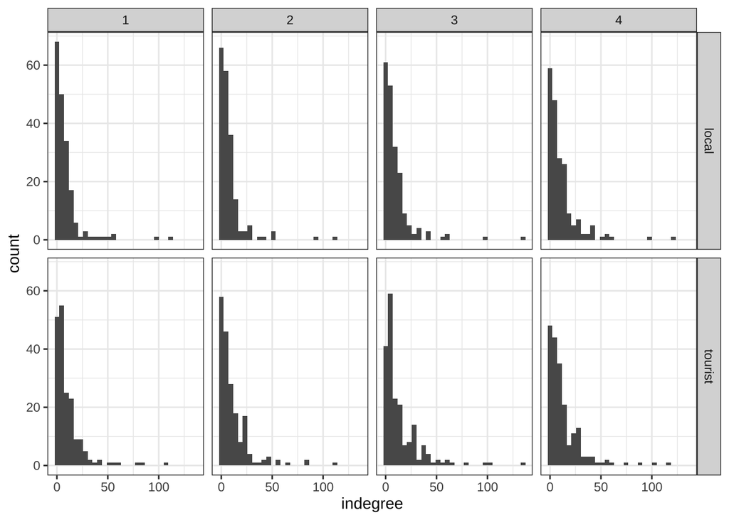

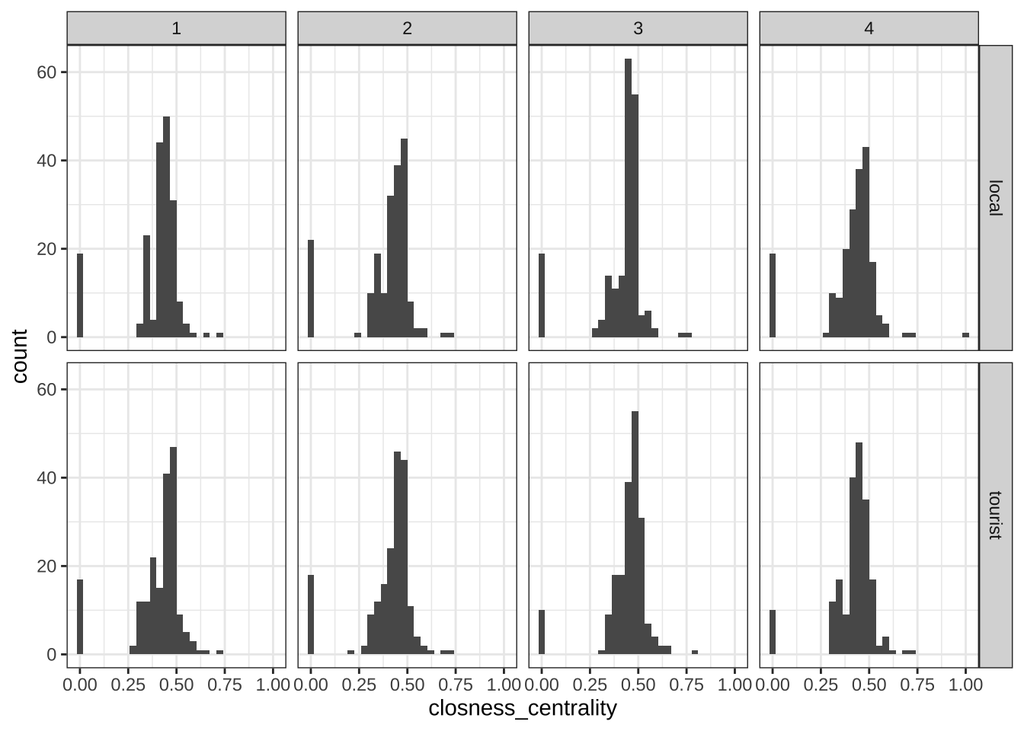

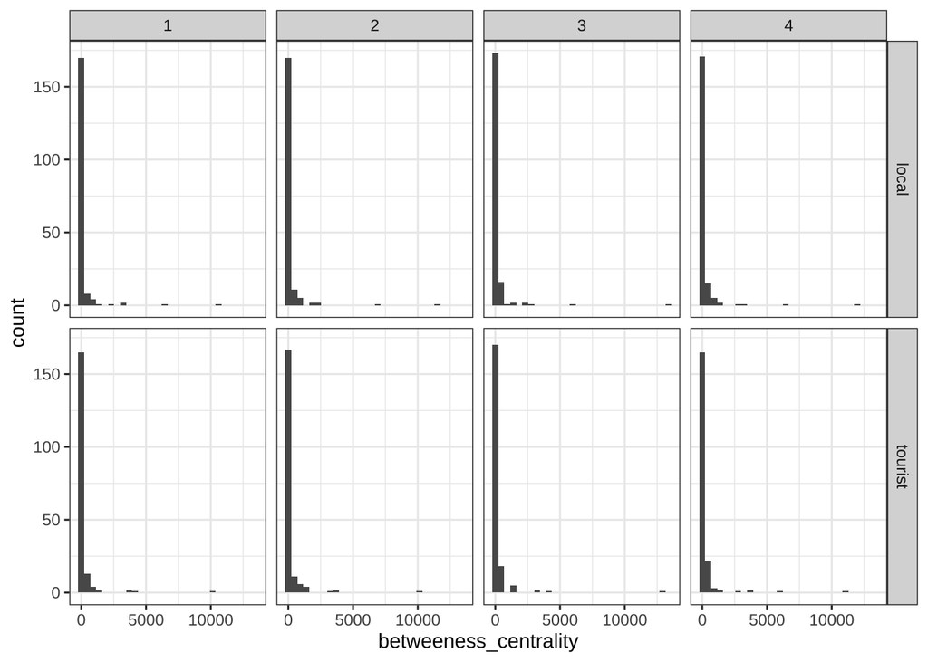

类似地，可以作相应的密度图。

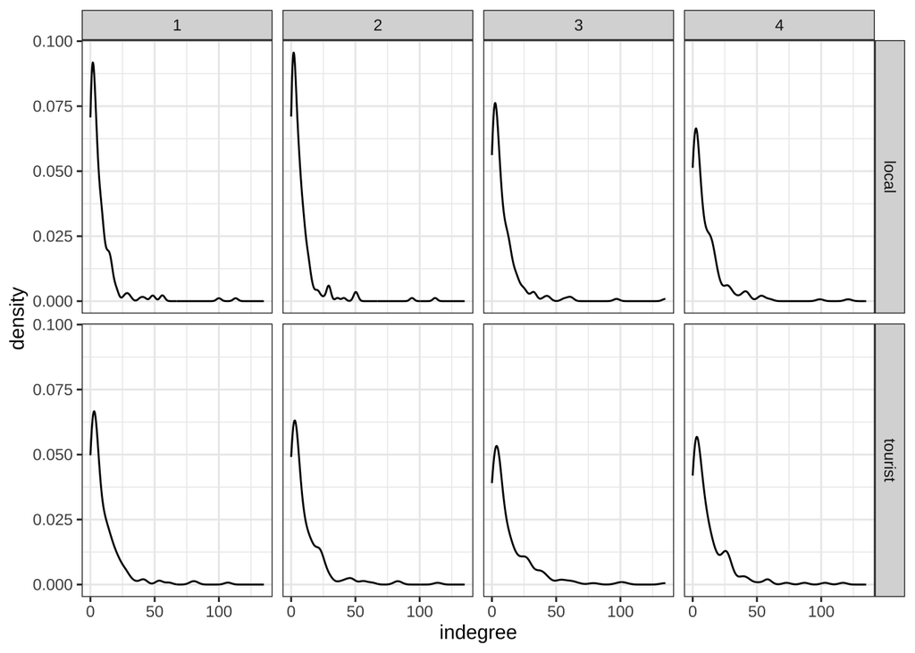

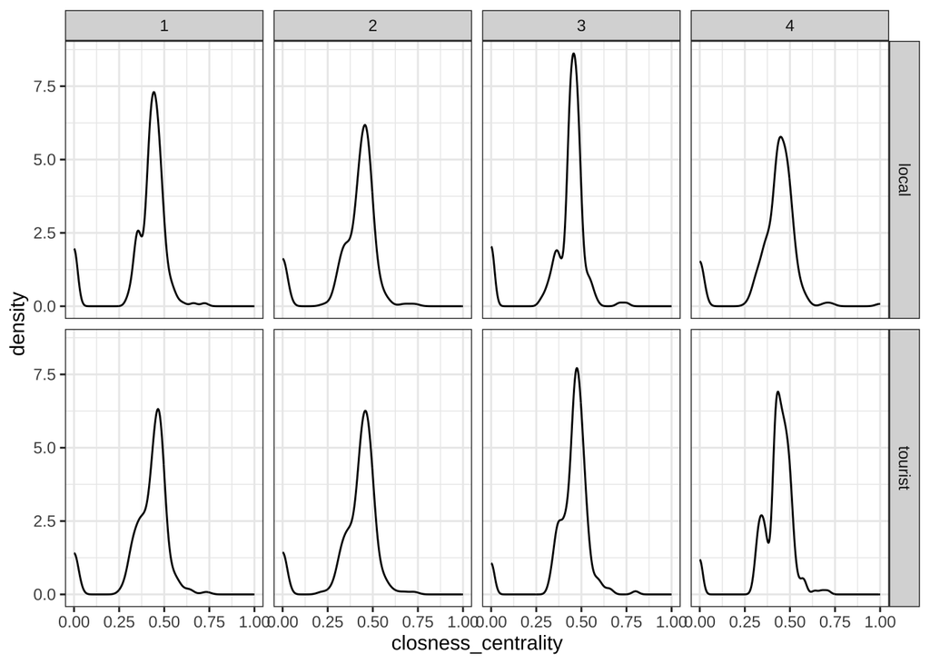

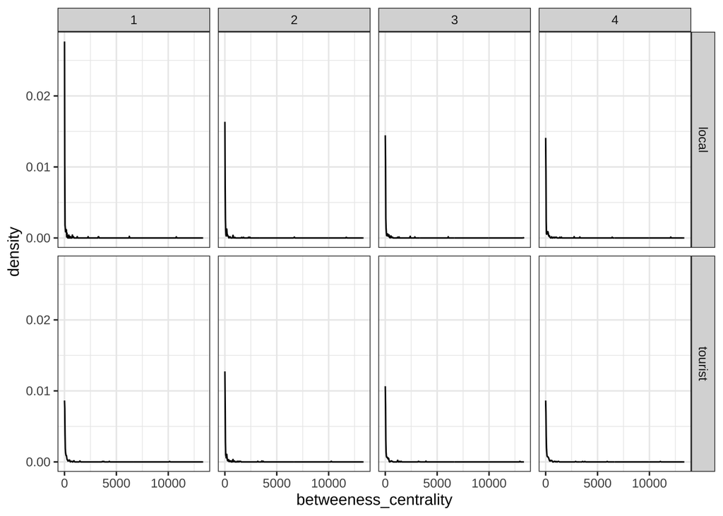

## 结果2

正如上次讨论的，我觉得目前选出来的3个指标有区分度，而且也有明确意涵。如果要用它们来衡量"需求"或者"热度"，跟"供给"（也就是各节点周边各类POI的供给）进行对比，是有意义的。目前的主要问题在于：各个指标分别代表什么"需求"？分析中，我们要对所有节点进行分析，还是挑出最重要的节点？

### 问题1：对应需求

从各节点网络指标含义上，基本上可以将指标和需求联系起来：（1）indgree表示多少人流入一个节点，因此可以表征"目的地热点"，而正如你说的，根据客源不同，又可进一步跟旅客POI或本地人POI联系起来；（2）betweenness表示这个点是否是人们路径上的"中介"或"中转点"，所以可以和交通枢纽联系；（3）closeness表示到其他所有点的"平均距离"，也就是说如果一个节点这个值越高，代表它到其他地方的可达性越高。后两者确实有类似之处，但是它们的主要区别在于：betweenness高意味着"要去某个地方，很可能要经过这个节点"，而closeness高则意味着"去很多地方都很近"；另一方面，两者其实是不太相关的（皮尔森相关系数仅为0.32），意味着betweenness高的点未必是closeness高的点。

### 问题2：如何分析

将网络指标和需求对应上后，后续可以按照最容易理解的思路进行分析：（1）对某一类需求，计算每个地点供给POI和网络指标值的比率，如果值越大说明供给率越高，反之越低；（2）不采用gephi的community分析，而是根据各地点地理上的实际物理距离，将地点分成不同的组团或功能区或者地理区，前者例如"市中心组团"、"农村旅游集中区"、"红树林旅游区"等，后者如"空港组团"、"南部组团"等；（3）根据网络指标、POI、两者比率，可以判断当前的功能分区和实际需求是否匹配，预期得到的结论示例："红树林旅游区indegree高而饭店供给不足"、"交通供给不足的地点主要分布于南部地区"等。

如果认同该分析思路，我们需要做的事情如下。

（1）合并地点并定义地理组团。目前的地点数量仍然太多，而且很多地点实际上是可以合并的（例如下图的几个地点），所以你能否手动合并地点，预计可将目前的200多个地点合并为50个地点甚至更少，这样就可以以人可以理解的方式进行后续分析。然后像上面说的那样，合并地点之后，将各地点分入一个功能区组团或者地区组团中。

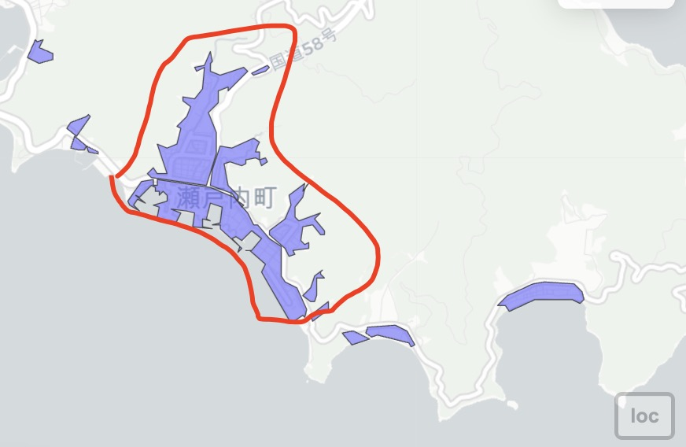

（2）谢提供各个地点对应的各类POI数量。

（3）康计算各地点分季度和客源的不同类型服务供给率，并且给出结果，至少应包含：各类供给率的空间分布；各地区组团中各供给率的分布情况。